# fibroscan

#### GGT

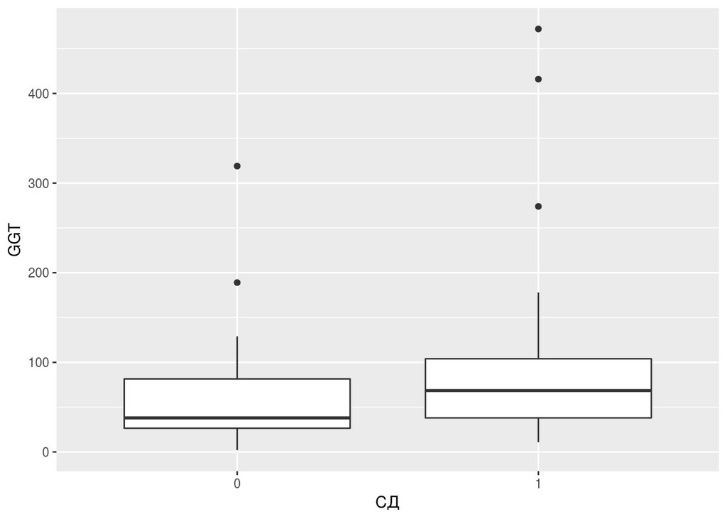

#### ALT

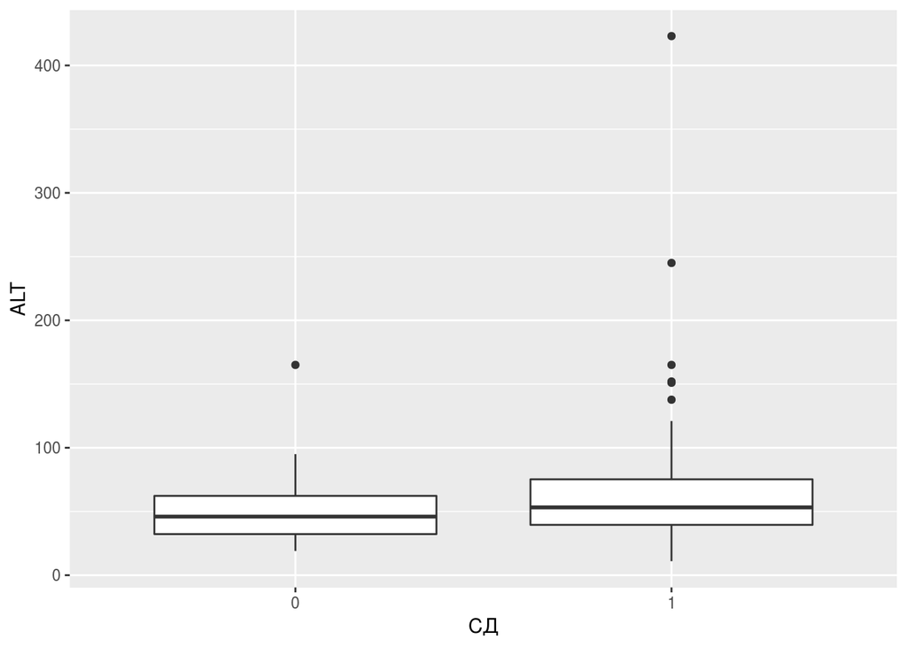

#### AST

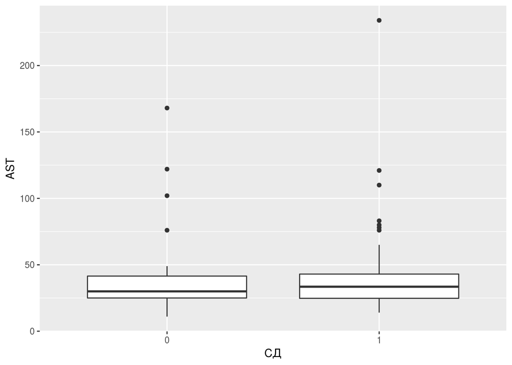

#### Glu

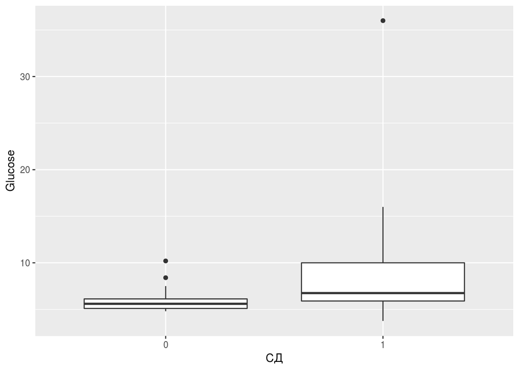

#### Cholesterol

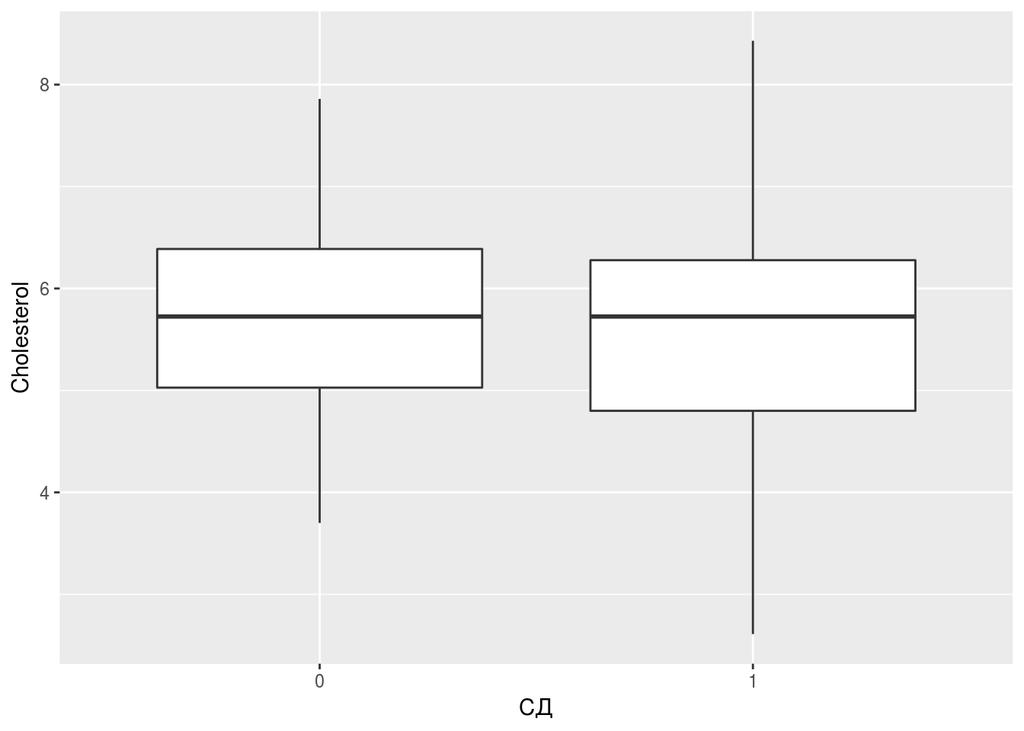

#### Trigl

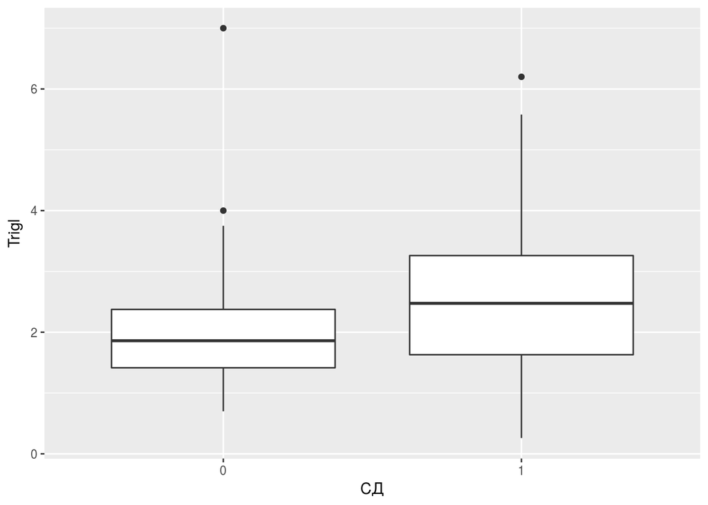

#### F1

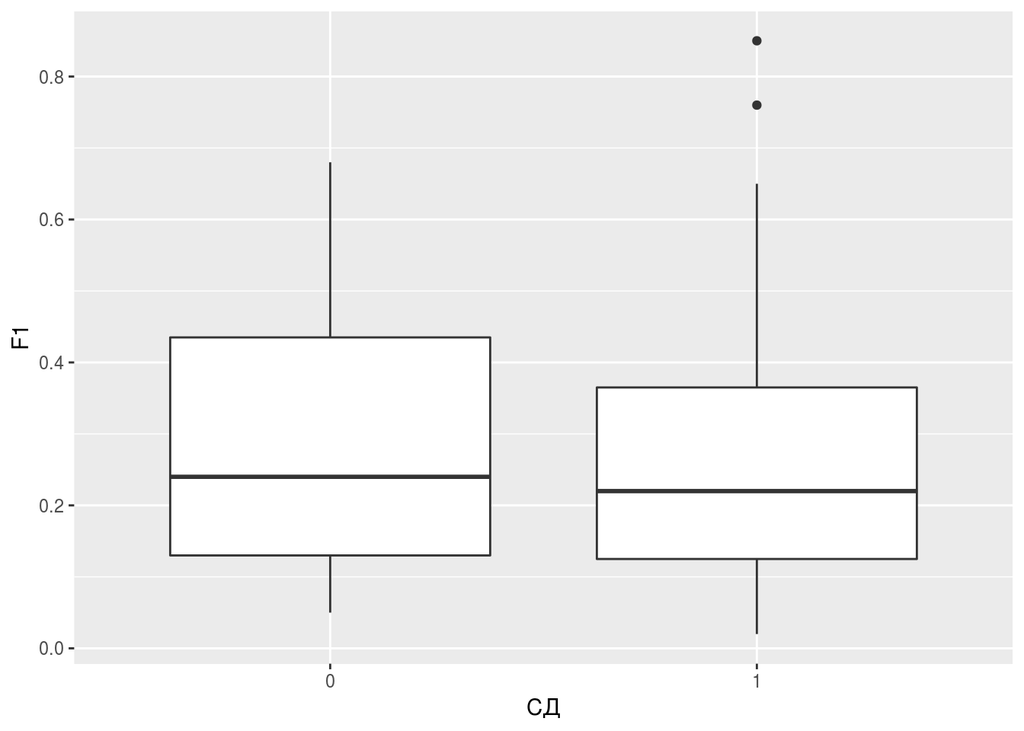

#### F1 + пол

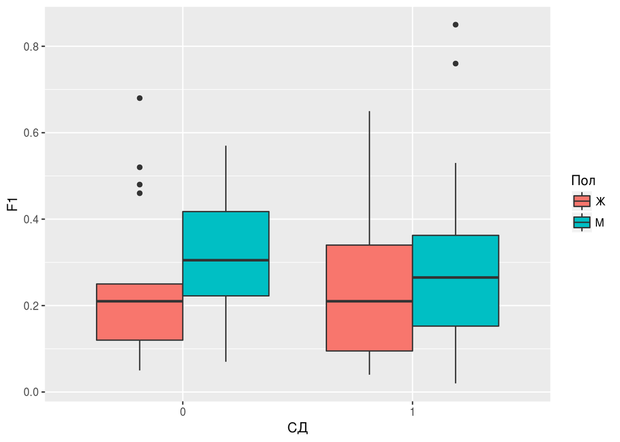

#### A1

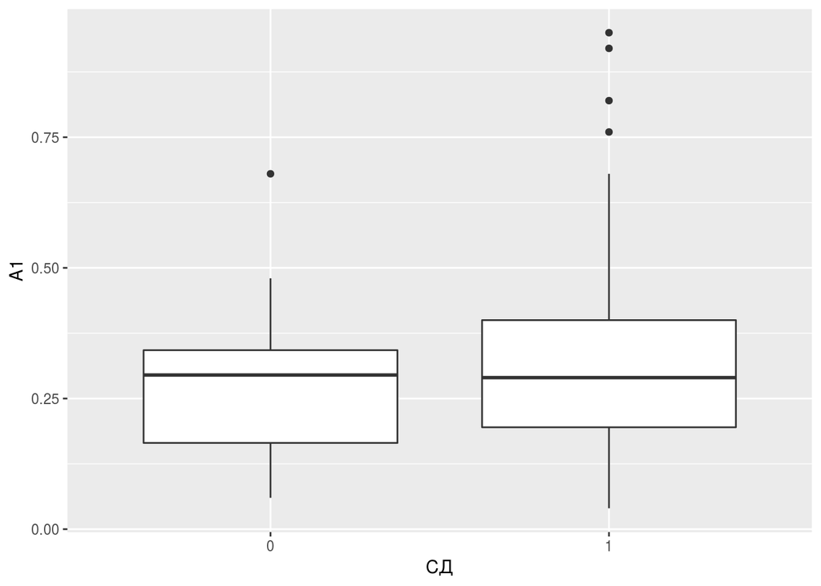

#### S1

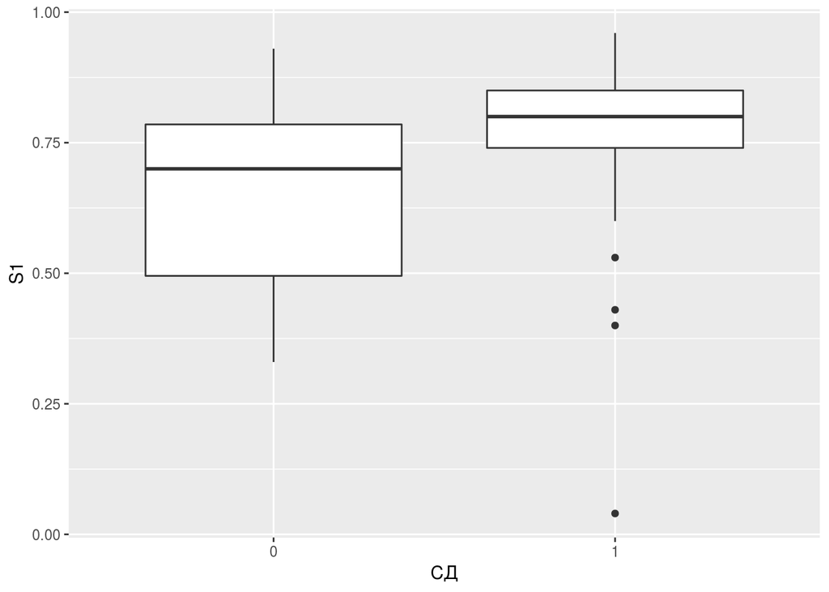

#### N1

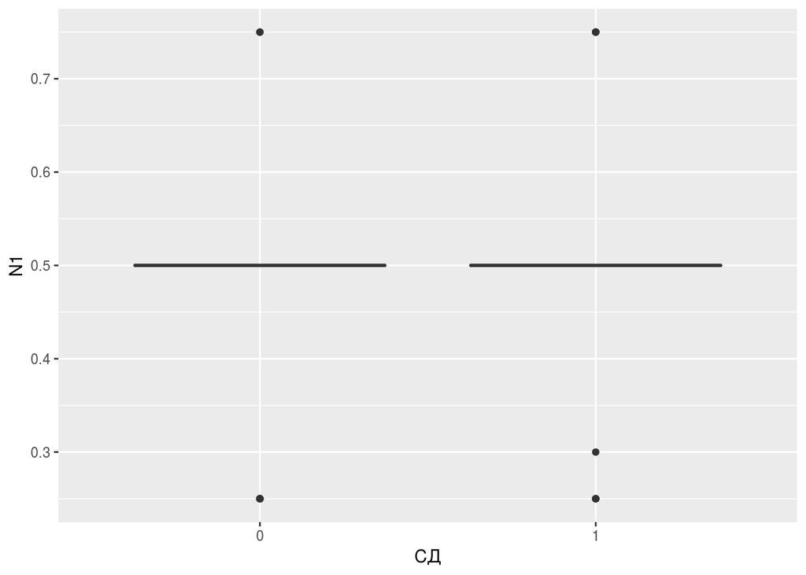

#### F.kPa

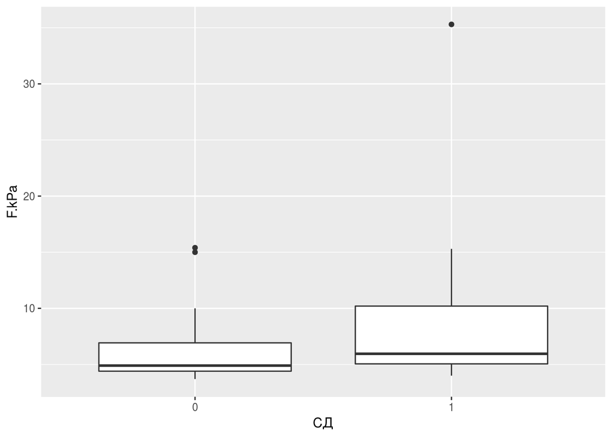

#### CAP

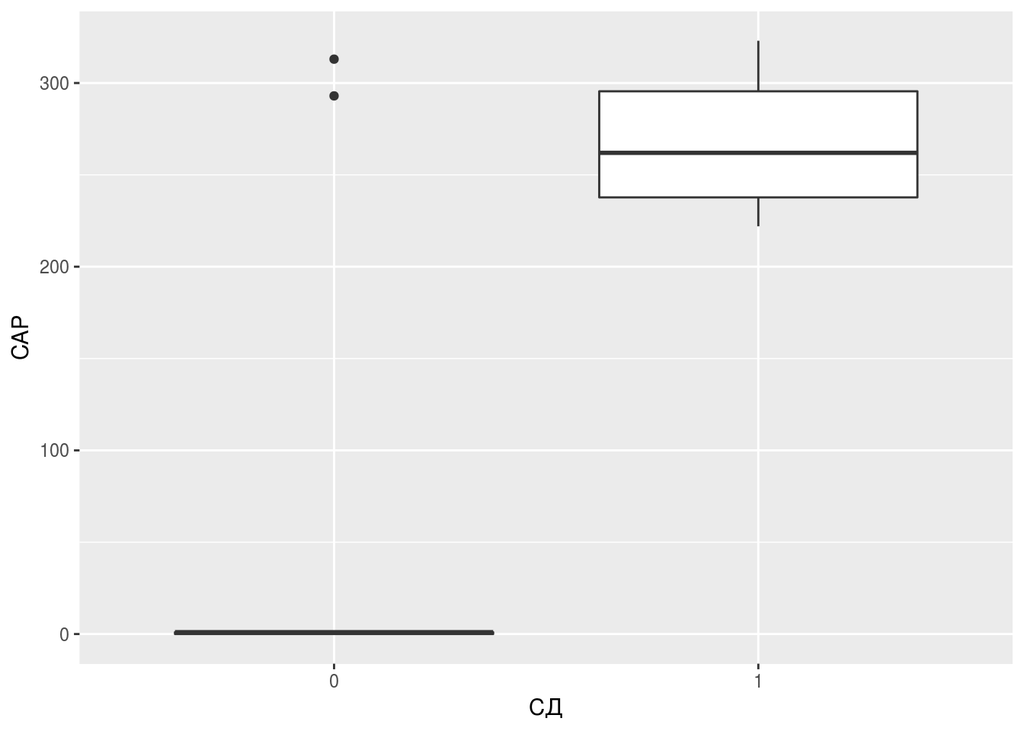

#### IQR

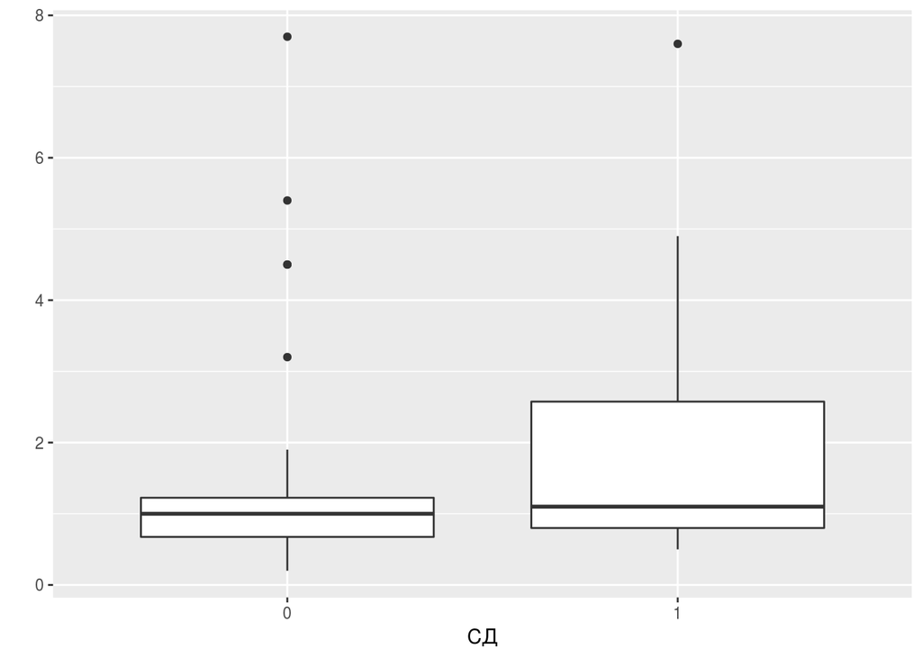

#### Plt

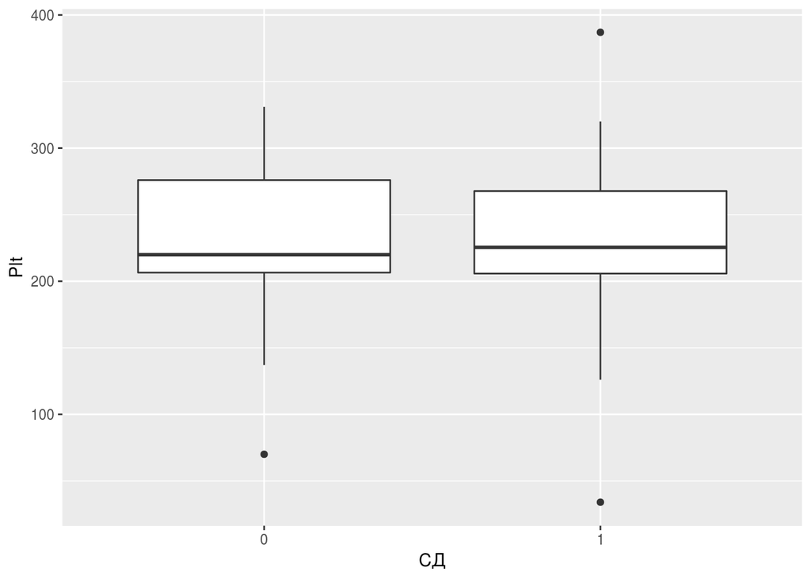

#### Протромбин

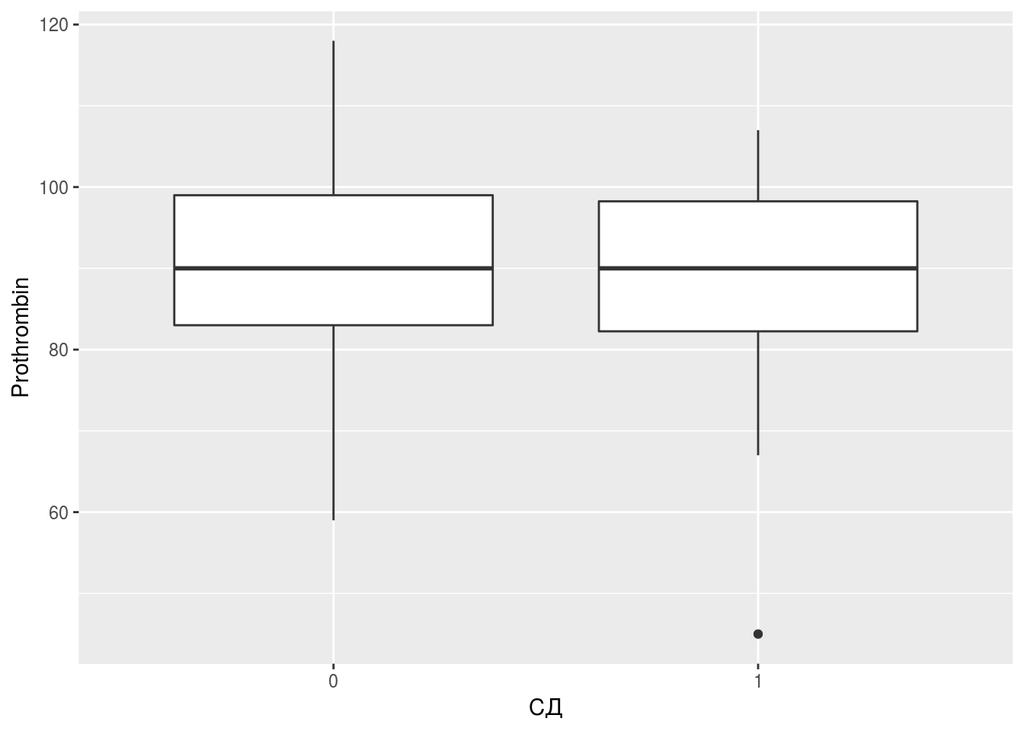

### Результаты теста Краскела-Уоллиса

| variable | statistic | pval | df | significant |
| --- | --- | --- | --- | --- |
| Growth | 0.0276090 | 0.8680315 | 1 | no |
| Weight | 9.0638981 | 0.0026071 | 1 | yes |
| BMI | 10.4218081 | 0.0012454 | 1 | yes |
| GG | 5.8929233 | 0.0152018 | 1 | yes |
| A2M | 0.0632713 | 0.8013983 | 1 | no |
| AA1 | 0.0158222 | 0.8999009 | 1 | no |
| BB | 2.2960185 | 0.1297061 | 1 | no |
| GGT | 5.5974457 | 0.0179867 | 1 | yes |
| ALT | 2.3040251 | 0.1290392 | 1 | no |
| AST | 0.1646158 | 0.6849419 | 1 | no |
| Glu | 10.8961778 | 0.0009636 | 1 | yes |
| Cholesterol | 0.1270329 | 0.7215285 | 1 | no |
| Trigl | 3.2342001 | 0.0721155 | 1 | no |
| F1 | 0.2399550 | 0.6242386 | 1 | no |
| A1 | 0.4859153 | 0.4857551 | 1 | no |
| S1 | 9.2805540 | 0.0023160 | 1 | yes |
| N1 | 1.0957124 | 0.2952090 | 1 | no |
| F.kPa | 4.8191362 | 0.0281454 | 1 | yes |
| CAP | 11.0762271 | 0.0008744 | 1 | yes |
| Age | 1.1718780 | 0.2790157 | 1 | no |
| IQR | 2.0944706 | 0.1478329 | 1 | no |
| Plt | 0.3442665 | 0.5573768 | 1 | no |
| prothrombin | 0.0005640 | 0.9810537 | 1 | no |
| steatosis | 0.6399262 | 0.4237375 | 1 | no |
| splenomegaly | 0.1140406 | 0.7355901 | 1 | no |
| SD | 67.0000000 | 0.0000000 | 1 | yes |

## Описательная статистика - трудоспособный возраст (от 18 до 60 лет включительно)

| SD | n | group | group_size | percent |
| --- | --- | --- | --- | --- |
| 0 | 26 | трудоспособные | 32 | 0.8125000 |
| 1 | 70 | трудоспособные | 116 | 0.6034483 |
| 0 | 6 | нетрудоспособные | 32 | 0.1875000 |
| 1 | 46 | нетрудоспособные | 116 | 0.3965517 |

**На графике**

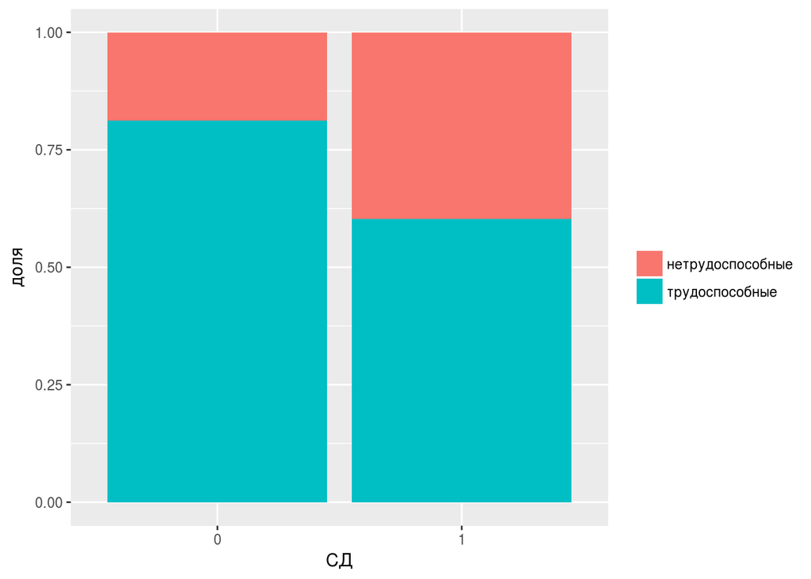

## Описательная статистика - число больных в группах менее и более 50 лет

| SD | n | group | group_size | percent |
| --- | --- | --- | --- | --- |
| 0 | 19 | <50 | 32 | 0.5937500 |
| 1 | 25 | <50 | 116 | 0.2155172 |
| 0 | 13 | >50 | 32 | 0.4062500 |
| 1 | 91 | >50 | 116 | 0.7844828 |

**На графике**

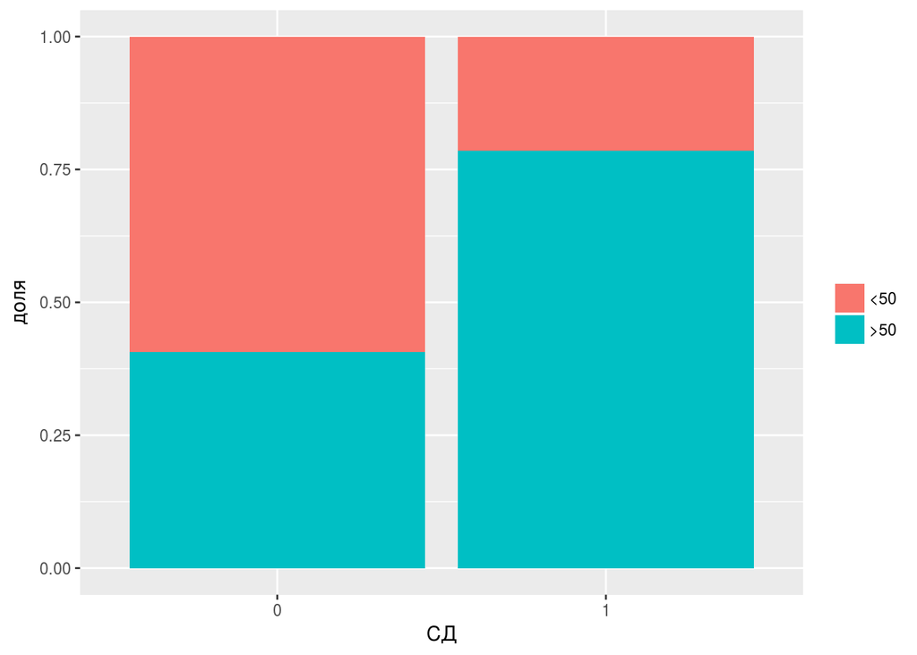

## Описательная статистика - число больных в интервале

### График

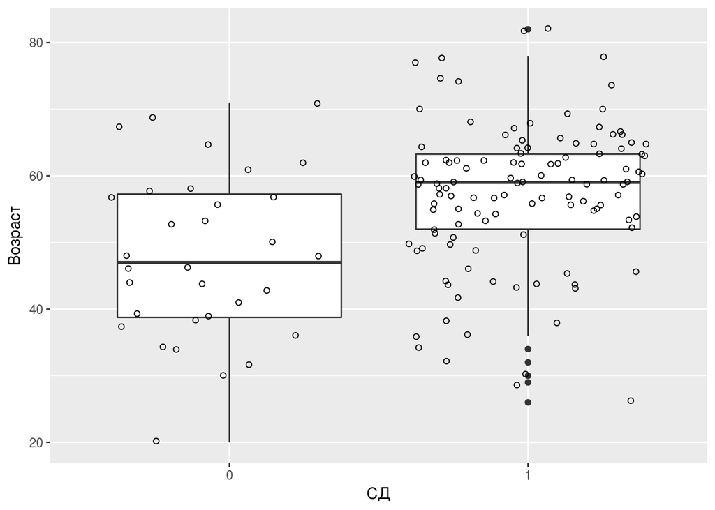

### Квантили

**Группа без SD**

```
##    0%   25%   50%   75%  100%
## 20.00 38.75 47.00 57.25 71.00
```

Число больных в возрасте между 38.75 и 57.25 - 16. Это половина всех наблюдений. Еще четверть больных в возрасте менее 38.75 и столько же в возрасте более 57.25.

**Группа с SD**

```
##    0%   25%   50%   75%  100%
## 26.00 52.00 59.00 63.25 82.00
```

Число больных в возрасте между 52 и 63.25 - 59.

## Сходимость методов (F)

### По всей выборке

**Таблица сопряженности**

```
##    Fscan
## F    0  1  2  3  4
##   0 27  9  6  3  4
##   1 22 12  6  1  2
##   2  5  9  5  2  7
##   3  2  0  0  5  2
##   4  0  0  0  2 17
```

**График сопряженности**

На графике видны отклонения ожидаемых частот от наблюдаемых величин (deviations from independence). Высота прямоугольника показывает абсолютную величину этого отклонения, а положение — знак отклонения. Чем выше столбики (высота над линией) по диагонали графика, тем сильнее выражена связь между двумя факторныим величинами.

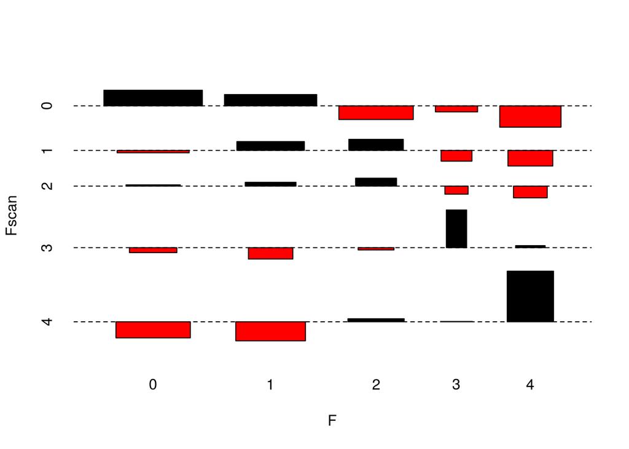

**Тест сопряженности Крамера**

```
##                      X^2 df   P(> X^2)
## Likelihood Ratio  95.656 16 2.2438e-13
## Pearson          105.448 16 3.2196e-15
##
## Phi-Coefficient   : NA
## Contingency Coeff.: 0.645
## Cramer's V        : 0.422
```

## Сопряженность в подгруппах: ИМТ до 25

Таблица сопряженности

```
##    Fscan
## F   0 1 4
##   0 3 1 0
##   1 2 0 0
##   2 0 1 0
##   3 1 0 0
##   4 0 0 1
```

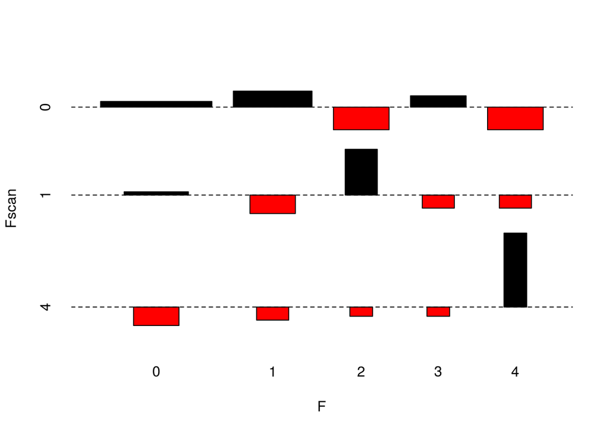

```
##                     X^2 df P(> X^2)
## Likelihood Ratio 10.778  8 0.214618
## Pearson          13.500  8 0.095765
##
## Phi-Coefficient   : NA
## Contingency Coeff.: 0.775
## Cramer's V        : 0.866
```

Связь сильная, отличия недостоверны

## Сопряженность в подгруппах: ИМТ до 30

Таблица сопряженности

```
##    Fscan
## F    0  1  2  3  4
##   0 11  3  2  1  0
##   1 13  3  2  0  1
##   2  1  4  2  0  0
##   3  1  0  0  1  0
##   4  0  0  0  0  5
```

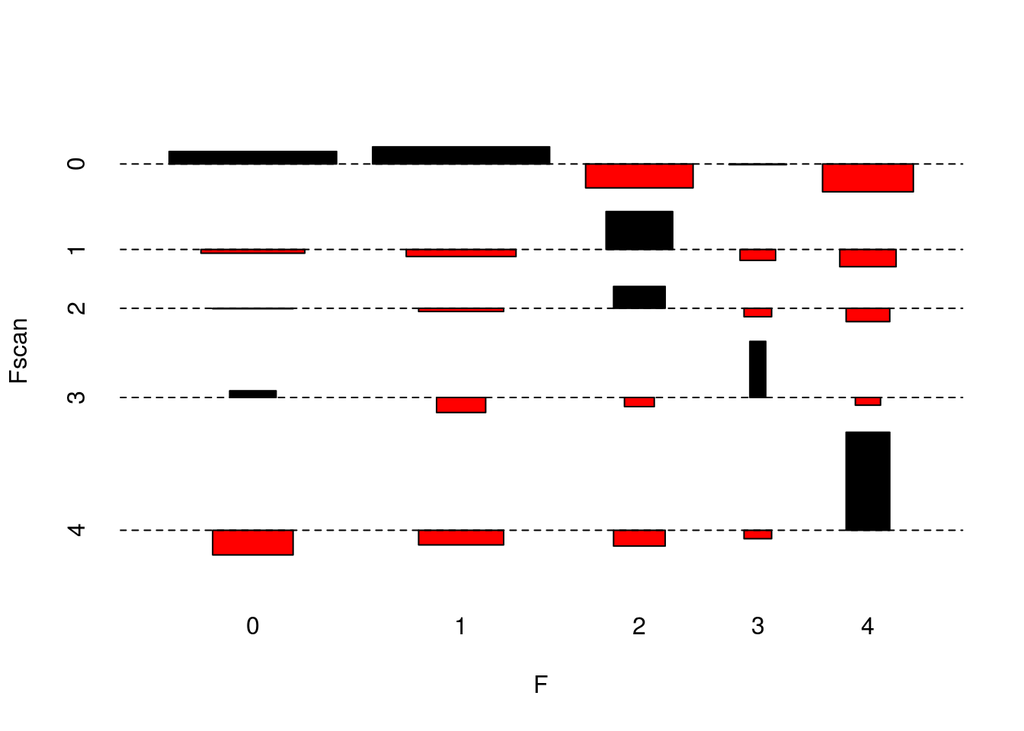

```
##                     X^2 df   P(> X^2)
## Likelihood Ratio 43.755 16 2.1486e-04
## Pearson          63.026 16 1.6052e-07
##
## Phi-Coefficient   : NA
## Contingency Coeff.: 0.747
## Cramer's V        : 0.561
```

Связь средней средней силы (0.561), достоверная при уровне значимости р=1.6052e-07

## Сопряженность в подгруппах: ИМТ более 30

Таблица сопряженности

```
##    Fscan
## F    0  1  2  3  4
##   0 16  6  4  2  4
##   1  9  9  4  1  1
##   2  4  5  3  2  7
##   3  1  0  0  4  2
##   4  0  0  0  2 12
```

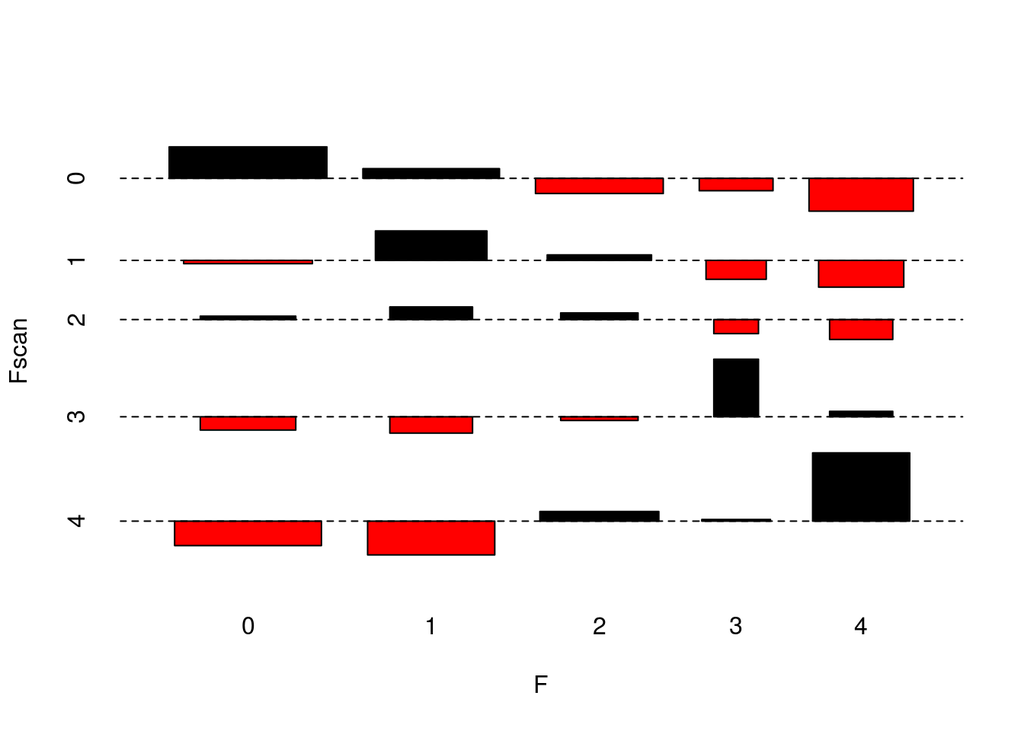

```
##                     X^2 df   P(> X^2)
## Likelihood Ratio 61.897 16 2.4997e-07
## Pearson          62.060 16 2.3452e-07
##
## Phi-Coefficient   : NA
## Contingency Coeff.: 0.623
## Cramer's V        : 0.398
```

Связь слабая (0.398), при уровне значимости р=2.3452e-07

# Регрессия

## Технические часть - можно не смотреть

### Проверка корреляции среди предикторов

|  | Growth | Weight | BMI | GG | A2M | AA1 | BB | GGT | ALT | AST | Glu | Cholesterol | Trigl |
| --- | --- | --- | --- | --- | --- | --- | --- | --- | --- | --- | --- | --- | --- |
| Growth | 1.00 | 0.46 | -0.22 | -0.16 | -0.21 | -0.18 | 0.28 | 0.22 | 0.22 | 0.11 | -0.20 | -0.24 | -0.04 |
| Weight | 0.46 | 1.00 | 0.70 | -0.05 | -0.12 | -0.19 | 0.19 | 0.21 | 0.25 | 0.14 | 0.03 | -0.07 | 0.08 |
| BMI | -0.22 | 0.70 | 1.00 | 0.12 | 0.04 | -0.08 | 0.03 | 0.08 | 0.09 | 0.08 | 0.17 | 0.10 | 0.09 |
| GG | -0.16 | -0.05 | 0.12 | 1.00 | -0.10 | 0.10 | -0.30 | 0.02 | -0.09 | -0.17 | 0.22 | 0.08 | 0.09 |
| A2M | -0.21 | -0.12 | 0.04 | -0.10 | 1.00 | 0.11 | 0.09 | 0.10 | -0.04 | 0.14 | 0.09 | 0.10 | -0.14 |
| AA1 | -0.18 | -0.19 | -0.08 | 0.10 | 0.11 | 1.00 | -0.22 | -0.07 | -0.07 | -0.14 | 0.22 | 0.15 | -0.18 |
| BB | 0.28 | 0.19 | 0.03 | -0.30 | 0.09 | -0.22 | 1.00 | 0.02 | 0.10 | 0.15 | -0.08 | -0.15 | -0.03 |
| GGT | 0.22 | 0.21 | 0.08 | 0.02 | 0.10 | -0.07 | 0.02 | 1.00 | 0.34 | 0.36 | 0.13 | 0.07 | 0.12 |
| ALT | 0.22 | 0.25 | 0.09 | -0.09 | -0.04 | -0.07 | 0.10 | 0.34 | 1.00 | 0.62 | 0.08 | 0.23 | 0.28 |
| AST | 0.11 | 0.14 | 0.08 | -0.17 | 0.14 | -0.14 | 0.15 | 0.36 | 0.62 | 1.00 | 0.02 | 0.09 | 0.17 |
| Glu | -0.20 | 0.03 | 0.17 | 0.22 | 0.09 | 0.22 | -0.08 | 0.13 | 0.08 | 0.02 | 1.00 | 0.20 | 0.23 |
| Cholesterol | -0.24 | -0.07 | 0.10 | 0.08 | 0.10 | 0.15 | -0.15 | 0.07 | 0.23 | 0.09 | 0.20 | 1.00 | 0.35 |
| Trigl | -0.04 | 0.08 | 0.09 | 0.09 | -0.14 | -0.18 | -0.03 | 0.12 | 0.28 | 0.17 | 0.23 | 0.35 | 1.00 |

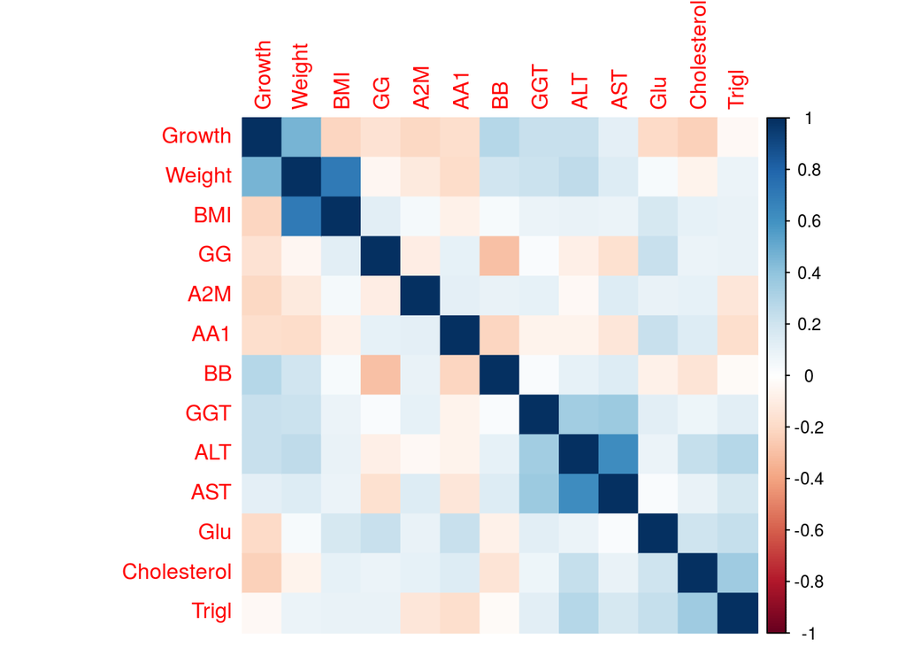

Исключаем Weight, Growth, ALT

|  | BMI | GG | A2M | AA1 | BB | GGT | AST | Glu | Cholesterol | Trigl |
| --- | --- | --- | --- | --- | --- | --- | --- | --- | --- | --- |
| BMI | 1.00 | 0.11 | 0.03 | -0.09 | 0.03 | 0.08 | 0.08 | 0.17 | 0.10 | 0.09 |
| GG | 0.11 | 1.00 | -0.10 | 0.10 | -0.30 | 0.02 | -0.17 | 0.22 | 0.08 | 0.09 |
| A2M | 0.03 | -0.10 | 1.00 | 0.12 | 0.08 | 0.10 | 0.14 | 0.10 | 0.10 | -0.14 |
| AA1 | -0.09 | 0.10 | 0.12 | 1.00 | -0.22 | -0.06 | -0.14 | 0.22 | 0.15 | -0.18 |
| BB | 0.03 | -0.30 | 0.08 | -0.22 | 1.00 | 0.02 | 0.15 | -0.08 | -0.15 | -0.03 |
| GGT | 0.08 | 0.02 | 0.10 | -0.06 | 0.02 | 1.00 | 0.36 | 0.14 | 0.07 | 0.12 |
| AST | 0.08 | -0.17 | 0.14 | -0.14 | 0.15 | 0.36 | 1.00 | 0.02 | 0.09 | 0.16 |
| Glu | 0.17 | 0.22 | 0.10 | 0.22 | -0.08 | 0.14 | 0.02 | 1.00 | 0.20 | 0.24 |
| Cholesterol | 0.10 | 0.08 | 0.10 | 0.15 | -0.15 | 0.07 | 0.09 | 0.20 | 1.00 | 0.35 |
| Trigl | 0.09 | 0.09 | -0.14 | -0.18 | -0.03 | 0.12 | 0.16 | 0.24 | 0.35 | 1.00 |

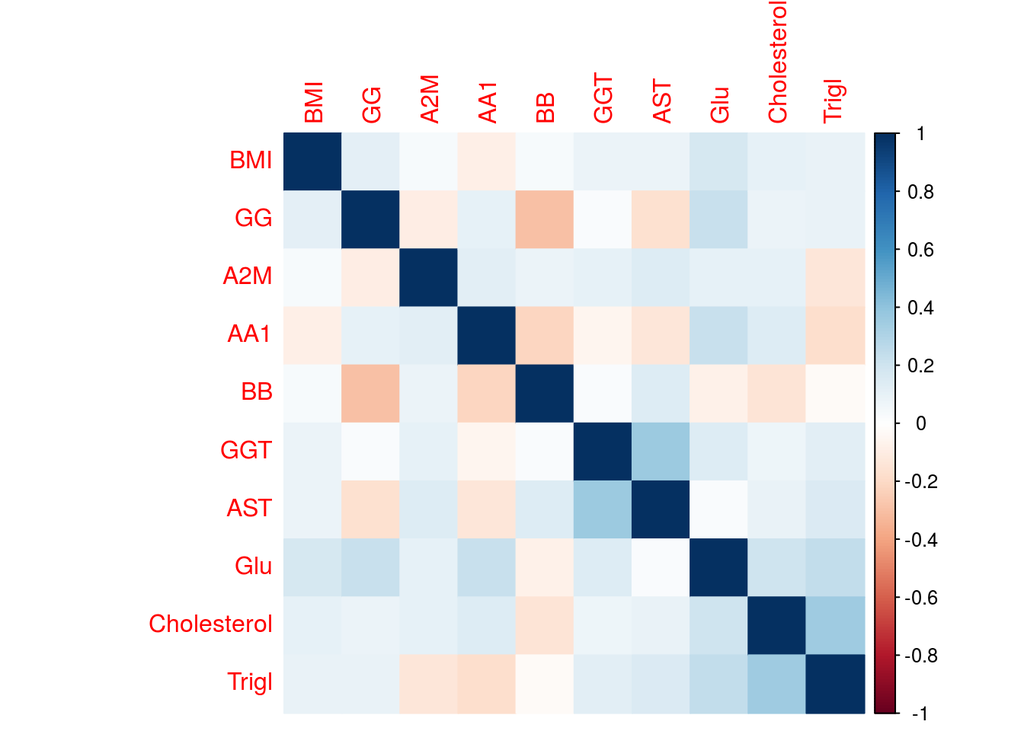

С этим можно работать.

## Модель для *F1*

### модель с трансформацией BB, GGT и GG

```
##
## Call:
## lm(formula = F1 ~ A2M + AA1 + I(log2(GG)) + I(log2(BB)) + I(log2(GGT)),
##     data = data_F1)
##
## Residuals:
##      Min       1Q   Median       3Q      Max
## -0.25024 -0.05892 -0.00633  0.05300  0.51107
##
## Coefficients:
##               Estimate Std. Error t value Pr(>|t|)
## (Intercept)  -0.194256   0.068508  -2.836  0.00526 **
## A2M           0.178847   0.009557  18.714  < 2e-16 ***
## AA1          -0.199459   0.025223  -7.908 7.56e-13 ***
## I(log2(GG))  -0.089033   0.012937  -6.882 1.89e-10 ***
## I(log2(BB))   0.077977   0.010518   7.413 1.12e-11 ***
## I(log2(GGT))  0.037265   0.006184   6.026 1.45e-08 ***
## ---
## Signif. codes:  0 '***' 0.001 '**' 0.01 '*' 0.05 '.' 0.1 ' ' 1
##
## Residual standard error: 0.103 on 138 degrees of freedom
##   (4 observations deleted due to missingness)
## Multiple R-squared:  0.8303, Adjusted R-squared:  0.8242
## F-statistic: 135.1 on 5 and 138 DF,  p-value: < 2.2e-16
```

#### диагностика

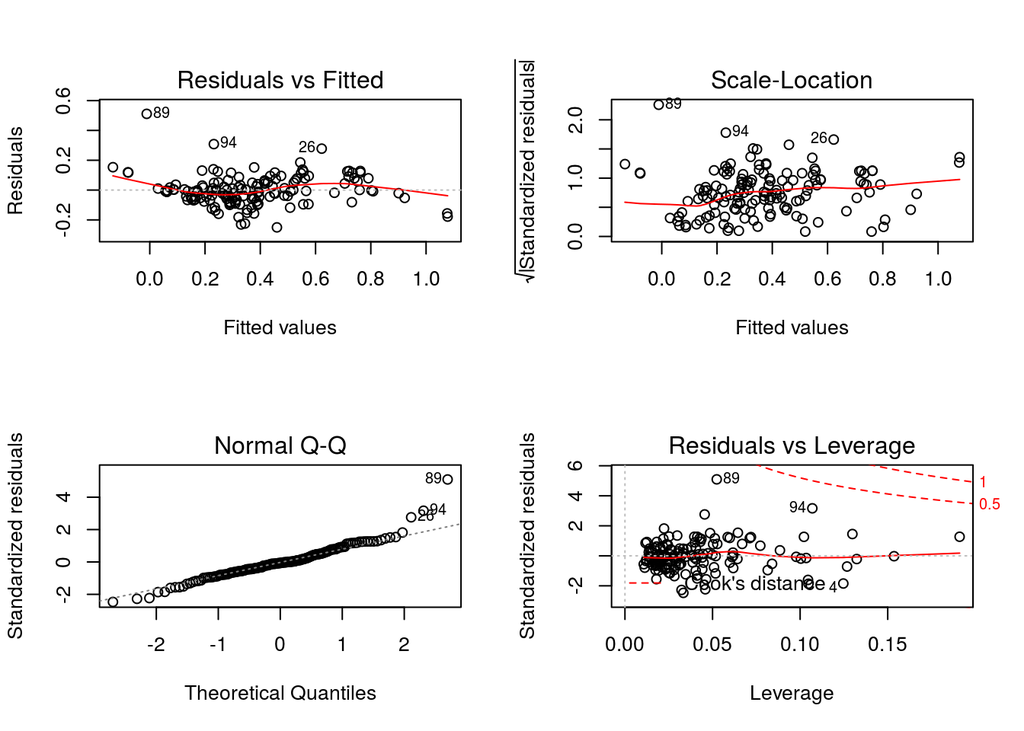

#### корреляция предсказаний модели и наблюдений

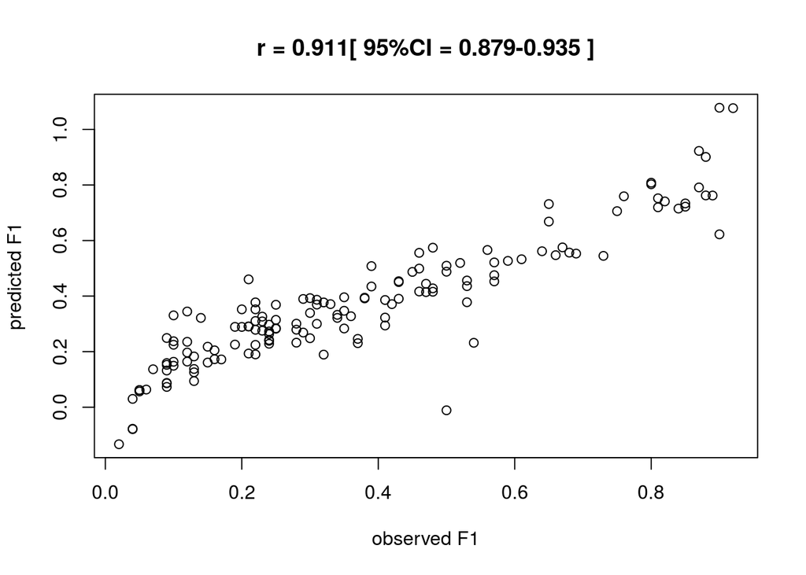

### Итоговая формула:

$F1 = -0.19 + 0.18\cdot A2M - 0.20\cdot AA1 - 0.09\cdot log{_2}(GG) + 0.08\cdot log{_2}(BB) + 0.04\cdot log{_2}(GGT)$

## A1

### простая модель

```
##
## Call:
## lm(formula = A1 ~ A2M + AA1 + BB + GGT + AST, data = data_A1)
##
## Residuals:
##      Min       1Q   Median       3Q      Max
## -0.68187 -0.09134 -0.00022  0.07885  0.65472
##
## Coefficients:
##               Estimate Std. Error t value Pr(>|t|)
## (Intercept)  0.1386007  0.0595300   2.328  0.02135 *
## A2M          0.0368870  0.0144212   2.558  0.01161 *
## AA1         -0.0954405  0.0372422  -2.563  0.01146 *
## BB           0.0012570  0.0007169   1.754  0.08173 .
## GGT          0.0004505  0.0001638   2.751  0.00675 **
## AST          0.0042043  0.0004257   9.877  < 2e-16 ***
## ---
## Signif. codes:  0 '***' 0.001 '**' 0.01 '*' 0.05 '.' 0.1 ' ' 1
##
## Residual standard error: 0.1536 on 138 degrees of freedom
##   (4 observations deleted due to missingness)
## Multiple R-squared:  0.574,  Adjusted R-squared:  0.5586
## F-statistic: 37.19 on 5 and 138 DF,  p-value: < 2.2e-16
```

### модель с трансформацией

```
##
## Call:
## lm(formula = A1 ~ A2M + I(log2(BB)) + I(log2(GGT)) + I(log2(AST)),
##     data = data_A1)
##
## Residuals:
##      Min       1Q   Median       3Q      Max
## -0.62941 -0.08324 -0.01395  0.07807  0.74859
##
## Coefficients:
##               Estimate Std. Error t value Pr(>|t|)
## (Intercept)  -0.881505   0.095906  -9.191 5.05e-16 ***
## A2M           0.028676   0.014143   2.028   0.0445 *
## I(log2(BB))   0.026626   0.014806   1.798   0.0743 .
## I(log2(GGT))  0.019083   0.009353   2.040   0.0432 *
## I(log2(AST))  0.181919   0.015950  11.405  < 2e-16 ***
## ---
## Signif. codes:  0 '***' 0.001 '**' 0.01 '*' 0.05 '.' 0.1 ' ' 1
##
## Residual standard error: 0.1514 on 139 degrees of freedom
##   (4 observations deleted due to missingness)
## Multiple R-squared:  0.583,  Adjusted R-squared:  0.571
## F-statistic: 48.59 on 4 and 139 DF,  p-value: < 2.2e-16
```

##### diagnostics

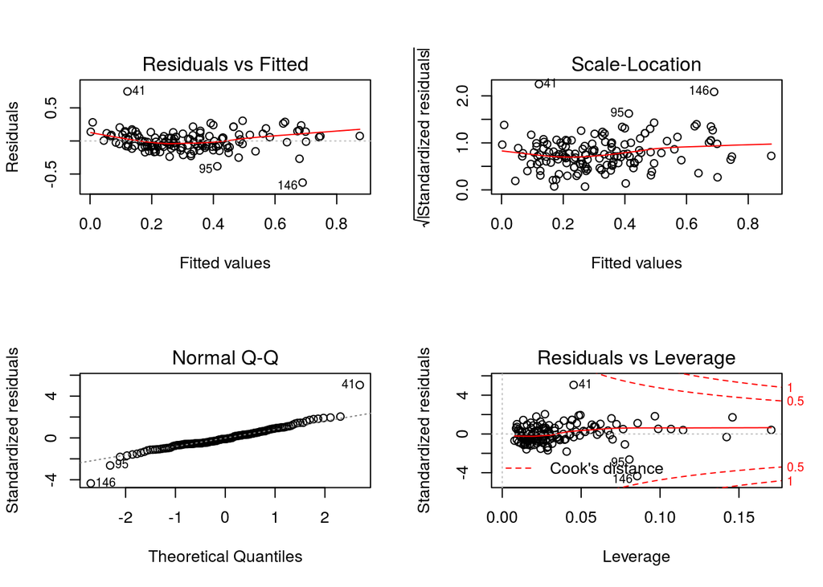

#### корреляция предсказаний модели с трансформацией и наблюдений

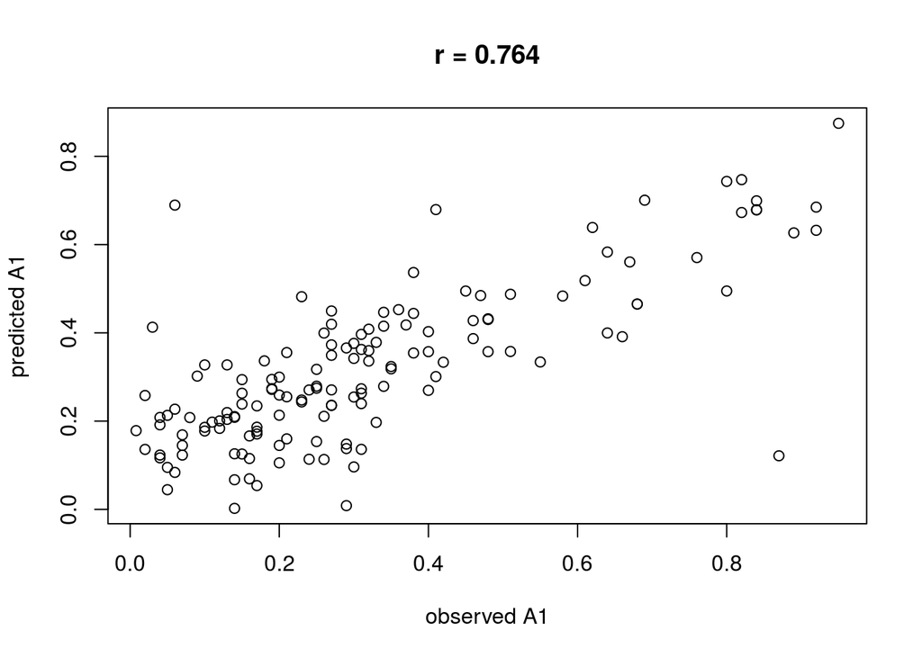

### Формула:

$A1 = A2M+log{_2}(BB)+log{_2}(GGT)+log{_2}(AST)$

## S1

### Все предикторы

```
##
## Call:
## lm(formula = S1 ~ BMI + A2M + BB + GGT + AA1 + AST + Glu + Cholesterol +
##     Trigl, data = data_S1)
##
## Residuals:
##      Min       1Q   Median       3Q      Max
## -0.37370 -0.07427  0.01737  0.07368  0.18643
##
## Coefficients:
##               Estimate Std. Error t value Pr(>|t|)
## (Intercept)  0.4462425  0.0773043   5.773 5.44e-08 ***
## BMI          0.0079516  0.0015535   5.119 1.08e-06 ***
## A2M         -0.0591537  0.0109339  -5.410 2.92e-07 ***
## BB           0.0003239  0.0005186   0.625  0.53338
## GGT          0.0006962  0.0001196   5.819 4.36e-08 ***
## AA1         -0.1963240  0.0287502  -6.829 2.96e-10 ***
## AST          0.0004861  0.0003213   1.513  0.13275
## Glu          0.0077836  0.0029059   2.679  0.00835 **
## Cholesterol  0.0259970  0.0092056   2.824  0.00549 **
## Trigl        0.0480950  0.0086799   5.541 1.60e-07 ***
## ---
## Signif. codes:  0 '***' 0.001 '**' 0.01 '*' 0.05 '.' 0.1 ' ' 1
##
## Residual standard error: 0.1096 on 130 degrees of freedom
##   (8 observations deleted due to missingness)
## Multiple R-squared:  0.6606, Adjusted R-squared:  0.6371
## F-statistic: 28.12 on 9 and 130 DF,  p-value: < 2.2e-16
```

### Только значимые

```
##
## Call:
## lm(formula = S1 ~ BMI + A2M + GGT + AA1 + Glu + Cholesterol +
##     Trigl, data = data_S1)
##
## Residuals:
##      Min       1Q   Median       3Q      Max
## -0.37003 -0.06807  0.01531  0.07663  0.18623
##
## Coefficients:
##               Estimate Std. Error t value Pr(>|t|)
## (Intercept)  0.4508875  0.0759237   5.939 2.40e-08 ***
## BMI          0.0080231  0.0015569   5.153 9.11e-07 ***
## A2M         -0.0563112  0.0108725  -5.179 8.12e-07 ***
## GGT          0.0007490  0.0001137   6.590 9.59e-10 ***
## AA1         -0.2005013  0.0287791  -6.967 1.39e-10 ***
## Glu          0.0074725  0.0029153   2.563  0.01149 *
## Cholesterol  0.0284789  0.0090686   3.140  0.00208 **
## Trigl        0.0497792  0.0086697   5.742 6.14e-08 ***
## ---
## Signif. codes:  0 '***' 0.001 '**' 0.01 '*' 0.05 '.' 0.1 ' ' 1
##
## Residual standard error: 0.1102 on 132 degrees of freedom
##   (8 observations deleted due to missingness)
## Multiple R-squared:  0.6519, Adjusted R-squared:  0.6335
## F-statistic: 35.32 on 7 and 132 DF,  p-value: < 2.2e-16
```

### С трансформацией

```
##
## Call:
## lm(formula = S1 ~ I(log2(BMI)) + A2M + I(log2(GGT)) + AA1 + Glu +
##     Cholesterol + Trigl, data = data_S1)
##
## Residuals:
##      Min       1Q   Median       3Q      Max
## -0.32318 -0.06678  0.01385  0.06385  0.32003
##
## Coefficients:
##               Estimate Std. Error t value Pr(>|t|)
## (Intercept)  -0.463129   0.198911  -2.328 0.021415 *
## I(log2(BMI))  0.198175   0.037658   5.263 5.60e-07 ***
## A2M          -0.051548   0.010927  -4.718 5.99e-06 ***
## I(log2(GGT))  0.039080   0.006779   5.765 5.50e-08 ***
## AA1          -0.198398   0.029170  -6.802 3.26e-10 ***
## Glu           0.008867   0.002930   3.027 0.002973 **
## Cholesterol   0.031054   0.009137   3.399 0.000896 ***
## Trigl         0.042061   0.008787   4.787 4.47e-06 ***
## ---
## Signif. codes:  0 '***' 0.001 '**' 0.01 '*' 0.05 '.' 0.1 ' ' 1
##
## Residual standard error: 0.1115 on 132 degrees of freedom
##   (8 observations deleted due to missingness)
## Multiple R-squared:  0.6438, Adjusted R-squared:  0.6249
## F-statistic: 34.08 on 7 and 132 DF,  p-value: < 2.2e-16
```

#### Корреляция с наблюдениями

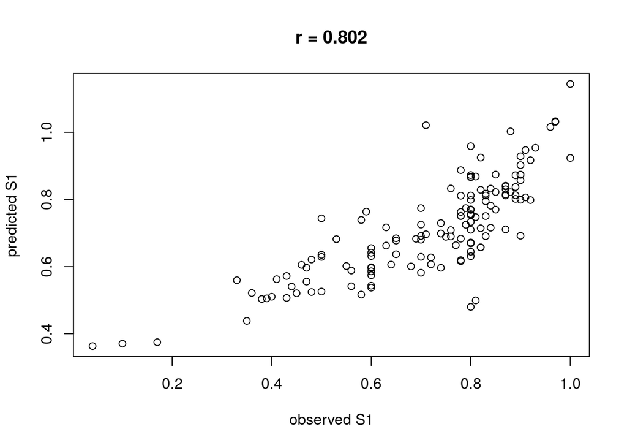

### Итоговая формула:

$S1 = log{_2}(BMI)+A2M+log{_2}(GGT)+AA1+Glu+Cholesterol+Trigl$

## N1

### Все предикторы

```
##
## Call:
## lm(formula = N1 ~ BMI + A2M + BB + GGT + AA1 + AST + Glu + Cholesterol +
##     Trigl, data = data_N1)
##
## Residuals:
##       Min        1Q    Median        3Q       Max
## -0.309270 -0.078959 -0.007657  0.073979  0.263672
##
## Coefficients:
##               Estimate Std. Error t value Pr(>|t|)
## (Intercept)  0.1658987  0.0986542   1.682   0.0950 .
## BMI          0.0039943  0.0019825   2.015   0.0460 *
## A2M          0.0233598  0.0139536   1.674   0.0965 .
## BB           0.0006213  0.0006619   0.939   0.3496
## GGT         -0.0002438  0.0001527  -1.597   0.1127
## AA1          0.0299014  0.0366904   0.815   0.4166
## AST          0.0002896  0.0004101   0.706   0.4813
## Glu          0.0073560  0.0037084   1.984   0.0494 *
## Cholesterol -0.0029788  0.0117480  -0.254   0.8002
## Trigl        0.0472488  0.0110771   4.265 3.81e-05 ***
## ---
## Signif. codes:  0 '***' 0.001 '**' 0.01 '*' 0.05 '.' 0.1 ' ' 1
##
## Residual standard error: 0.1399 on 130 degrees of freedom
##   (8 observations deleted due to missingness)
## Multiple R-squared:  0.2304, Adjusted R-squared:  0.1771
## F-statistic: 4.324 on 9 and 130 DF,  p-value: 6.119e-05
```

### Только значимые

```
##
## Call:
## lm(formula = N1 ~ I(log2(Glu)) + I(log2(Trigl)), data = data_N1)
##
## Residuals:
##      Min       1Q   Median       3Q      Max
## -0.34135 -0.09234 -0.00465  0.08705  0.26903
##
## Coefficients:
##                Estimate Std. Error t value Pr(>|t|)
## (Intercept)     0.25808    0.06969   3.703 0.000307 ***
## I(log2(Glu))    0.06960    0.02421   2.875 0.004677 **
## I(log2(Trigl))  0.08013    0.01572   5.096 1.12e-06 ***
## ---
## Signif. codes:  0 '***' 0.001 '**' 0.01 '*' 0.05 '.' 0.1 ' ' 1
##
## Residual standard error: 0.1355 on 138 degrees of freedom
##   (7 observations deleted due to missingness)
## Multiple R-squared:  0.2335, Adjusted R-squared:  0.2224
## F-statistic: 21.02 on 2 and 138 DF,  p-value: 1.076e-08
```

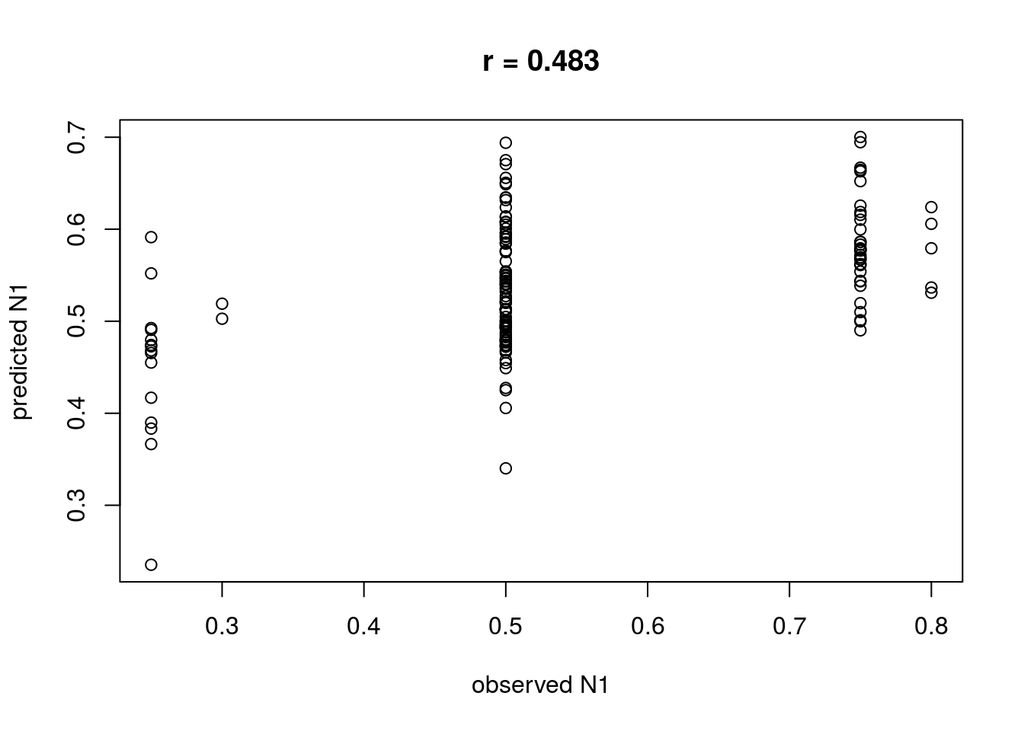